# FAT Lab FDA

### 19BCE1560

### 6th December, 2021

### Dr. B. Radhika Selvamani

```r
library(dplyr)
library(tidyverse)
```

## Index

Click to go to the respective Question  
1. Part 1  
2. Part 2

## Part 1

1. Read the given table. Print the number of rows and colums. Order the table based on volume. Remove duplicates and print the number of rows and columns

```r
df=read.csv("treesQ1.csv",header=TRUE)
colnames(df)
```

```
## [1] "Index"            "X..Girth..in.."   "X..Height..ft.."  "X..Volume.ft.3.."
```

```r
df = df %>%
  rename(
    Girth = X..Girth..in..,
    Height=X..Height..ft..,
    Volume=X..Volume.ft.3..
    )
nrow(df)
```

```
## [1] 35
```

```r
ncol(df)
```

```
## [1] 4
```

Order by Volume

```r
df=df[order(df$Volume),]
df
```

```
##    Index Girth Height Volume
## 3      3   8.8     63   10.2
## 1      1   8.3     70   10.3
## 2      2   8.6     65   10.3
## 7      7  11.0     66   15.6
## 4      4  10.5     72   16.4
## 8      8  11.0     75   18.2
## 5      5  10.7     81   18.8
## 17    15  12.0     75   19.1
## 6      6  10.8     83   19.7
## 11    10  11.2     75   19.9
## 13    12  11.4     76   21.0
## 16    14  11.7     69   21.3
## 15    13  11.4     76   21.4
## 18    16  12.9     74   22.2
```

[output cut: 21 more lines]

Remove duplicates

```r
df=df[!duplicated(df),]
df
```

```
##    Index Girth Height Volume
## 3      3   8.8     63   10.2
## 1      1   8.3     70   10.3
## 2      2   8.6     65   10.3
## 7      7  11.0     66   15.6
## 4      4  10.5     72   16.4
## 8      8  11.0     75   18.2
## 5      5  10.7     81   18.8
## 17    15  12.0     75   19.1
## 6      6  10.8     83   19.7
## 11    10  11.2     75   19.9
## 13    12  11.4     76   21.0
## 16    14  11.7     69   21.3
## 15    13  11.4     76   21.4
## 18    16  12.9     74   22.2
```

[output cut: 17 more lines]

Number of rows and columns

```r
nrow(df)
```

```
## [1] 31
```

```r
ncol(df)
```

```
## [1] 4
```

2. Add a new column “grade” which categorizes the tree based on the volume as below 20 (SMALL) Below 30 and 20 and above (MEDIUM), above 30 (LARGE)

```r
df$grade = cut(df$Volume,breaks=c(-Inf,20,30,Inf), labels=c("SMALL","MEDIUM","LARGE"))
df
```

```
##    Index Girth Height Volume  grade
## 3      3   8.8     63   10.2  SMALL
## 1      1   8.3     70   10.3  SMALL
## 2      2   8.6     65   10.3  SMALL
## 7      7  11.0     66   15.6  SMALL
## 4      4  10.5     72   16.4  SMALL
## 8      8  11.0     75   18.2  SMALL
## 5      5  10.7     81   18.8  SMALL
## 17    15  12.0     75   19.1  SMALL
## 6      6  10.8     83   19.7  SMALL
## 11    10  11.2     75   19.9  SMALL
## 13    12  11.4     76   21.0 MEDIUM
## 16    14  11.7     69   21.3 MEDIUM
## 15    13  11.4     76   21.4 MEDIUM
## 18    16  12.9     74   22.2 MEDIUM
```

[output cut: 17 more lines]

3. Group by the table by column “grade” and and calculate the mean girth and height within each category. Draw a box plot for the same.

```r
grp=df %>% group_by(grade) %>% summarise(avg_girth=mean(Girth),avg_height=mean(Height))
grp
```

```
## # A tibble: 3 x 3
##   grade  avg_girth avg_height
##   <fct>      <dbl>      <dbl>
## 1 SMALL       10.3       72.5
## 2 MEDIUM      12.3       75
## 3 LARGE       16.4       79.7
```

Boxplot

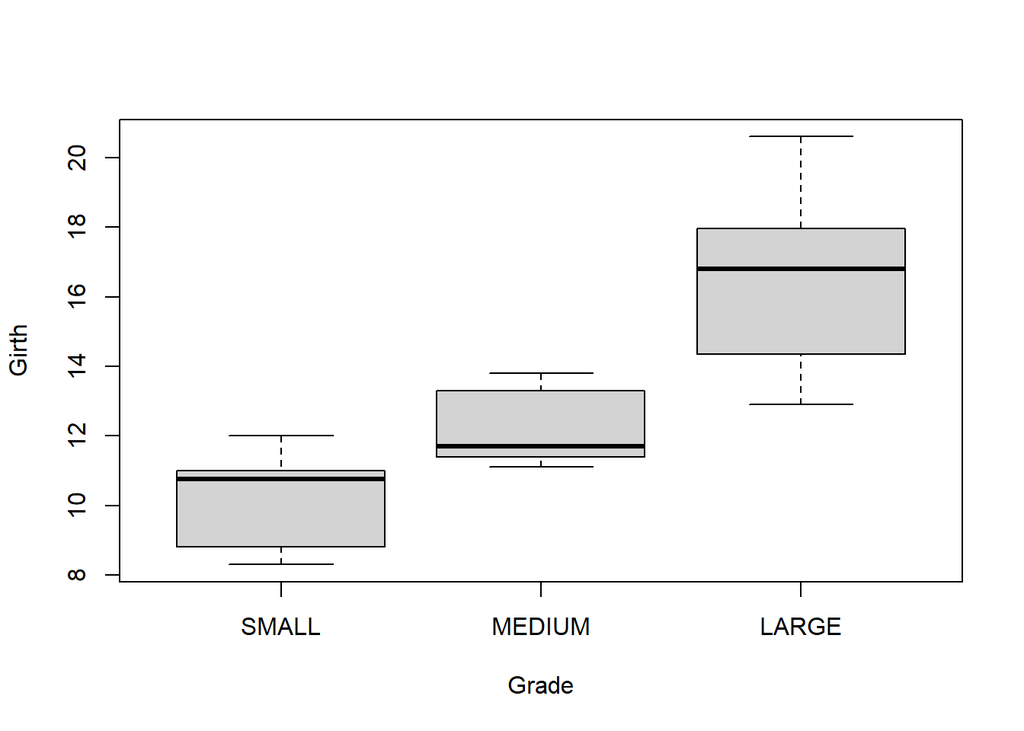

```r
boxplot(Girth~grade,data=df,xlab="Grade",ylab="Girth")
```

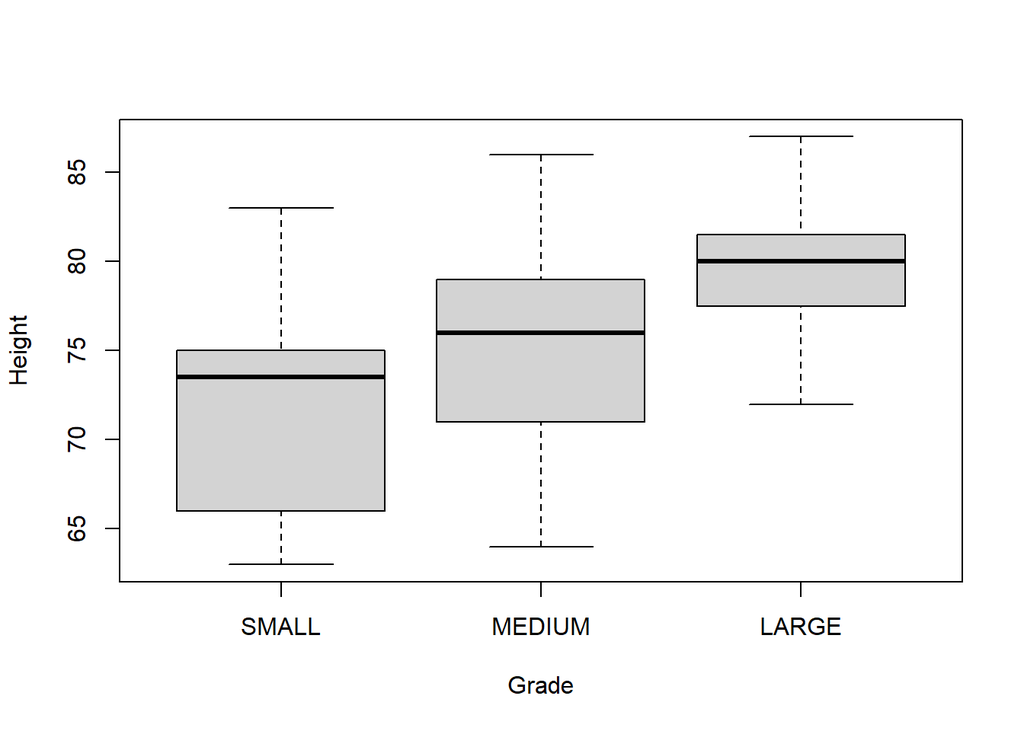

```r
boxplot(Height~grade,data=df,xlab="Grade",ylab="Height")
```

## Question 2

1. For the given table airtravels some values of missing. Please fill them using mean imputation and linear regression imputation. Identify the closest match among both

```r
df=read.csv("airtravelQ1.csv",header=TRUE)

df = df %>%
  rename(
    Month = Month,
    X1958=X..1958.,
    X1959=X..1959.
    )
df
```

```
##    Month X1958 X1959
## 1    JAN   340   360
## 2    FEB    NA   342
## 3    MAR   362   406
## 4    APR   348   396
## 5    MAY   363   420
## 6    JUN    NA   472
## 7    JUL   491   548
## 8    AUG   505   559
## 9    SEP   404   463
## 10   OCT    NA   407
## 11   NOV   310   362
## 12   DEC   337   405
```

```r
sum(is.na(df))
```

```
## [1] 3
```

Mean imputation of X1958

```r
df1=df
df1$X1958[is.na(df1$X1958)]=mean(df1$X1958,na.rm=TRUE)
df1
```

```
##    Month    X1958 X1959
## 1    JAN 340.0000   360
## 2    FEB 384.4444   342
## 3    MAR 362.0000   406
## 4    APR 348.0000   396
## 5    MAY 363.0000   420
## 6    JUN 384.4444   472
## 7    JUL 491.0000   548
## 8    AUG 505.0000   559
## 9    SEP 404.0000   463
## 10   OCT 384.4444   407
## 11   NOV 310.0000   362
## 12   DEC 337.0000   405
```

Linear regression imputation

```r
lm(X1958~X1959,data=df1)
```

```
##
## Call:
## lm(formula = X1958 ~ X1959, data = df1)
##
## Coefficients:
## (Intercept)        X1959
##      64.047        0.748
```

So using the coefficient and intercept

```r
df1=df
for(i in 1:nrow(df1))
{
  if(is.na(df1$X1958[i]))
  {
    df1$X1958[i]=(0.748*df1$X1959[i])+(64.047)
  }
}
df1
```

```
##    Month   X1958 X1959
## 1    JAN 340.000   360
## 2    FEB 319.863   342
## 3    MAR 362.000   406
## 4    APR 348.000   396
## 5    MAY 363.000   420
## 6    JUN 417.103   472
## 7    JUL 491.000   548
## 8    AUG 505.000   559
## 9    SEP 404.000   463
## 10   OCT 368.483   407
## 11   NOV 310.000   362
## 12   DEC 337.000   405
```

The mean imputation is worse because it does not preserve any existing relationship between variables. Thus, linear regression imputation is the better method.